# Challenge 4: Figure for outreach

Solene Derville - solene.derville@oregonstate.edu

Feb 28, 2023

### Load R libraries

```r
library(tidyverse)
library(ggpubr)
library(patchwork)
library(raster)
library(ggridges)
library(ggthemes)
library(knitr)
```

### Load dataset

Extracted from GBIF: GBIF.org (09 May 2021) GBIF Occurrence Download https://doi.org/10.15468/dl.frb56w This file contains all GBIF occurrences of the Felidae family collected in Oregon (approximated by a box of longitude [-128.6, -119.3] and latitude [41.1, 46.2]), from 1900 to present (filtering out occurrences with uncertain coordinates)

```r
# import the csv in R into a dataframe. The .csv file needs to be in your working directory for this to work
# to change working directory, click on > Session > Set Working Directory > Choose Working Directory
dfel <- read.csv("dataset1_GBIF_observations.csv", sep = ";")

# this dataset has many columns, some of which are not necessary here so let's simplify the dataframe by selecting specific columns
dfel <- dfel %>%
  dplyr::select(gbifID, family, genus, species, individualCount, decimalLatitude, decimalLongitude, eventDate, month, year, institutionCode)
```

Extracting the elevation at the position where Felidae species were observed

```r
# elevation downloaded from GEBCO
# this object is in raster format
r <- raster("dataset2_gebco_map.tif")

# extract elevation and add it as a column in your dataframe d
dfel$elev <- raster::extract(r, dfel[c("decimalLongitude", "decimalLatitude")])

# for the purpose of these exercises, let's simply remove the observations for which elevation was not extracted
# there are couple observations with elev < 0 that don't make sense, let's set this to 0
dfel <- dfel %>%
  filter(!is.na(elev)) %>%
  mutate(elev = ifelse(elev < 0, 0, elev))
```

## Challenge objective: Design a visual for the general public comparing the altitude at which Felidae species are found in Oregon.

### Path to a figure for outreach

1. Compare the response variable with the chart type of your choice, using for instance: `geom_boxplot`, `ggridges::geom_density_ridges`, `geom_violin`, `geom_linerange`, `geom_bar` etc.
2. Set a transparent background in your ggplot using `theme(panel.background = element_rect(fill = 'transparent', colour = NA), plot.background = element_rect(fill = "transparent", colour = NA)`
3. Save the figure at high resolution in png format with transparent background with `ggsave(..., bg = 'transparent')`
4. Go to canva.com, choose a “Facebook post” template and produce a design based on your R figure. You can reproduce your plot’s colors in canva using the html codes

### A few tips

- Some ideas if you want to add color: https://www.canva.com/learn/100-color-combinations/ or https://github.com/EmilHvitfeldt/r-color-palettes
- Tips for using patchork: https://www.datanovia.com/en/blog/ggplot-multiple-plots-made-ridiculuous-simple-using-patchwork-r-package/

### Example

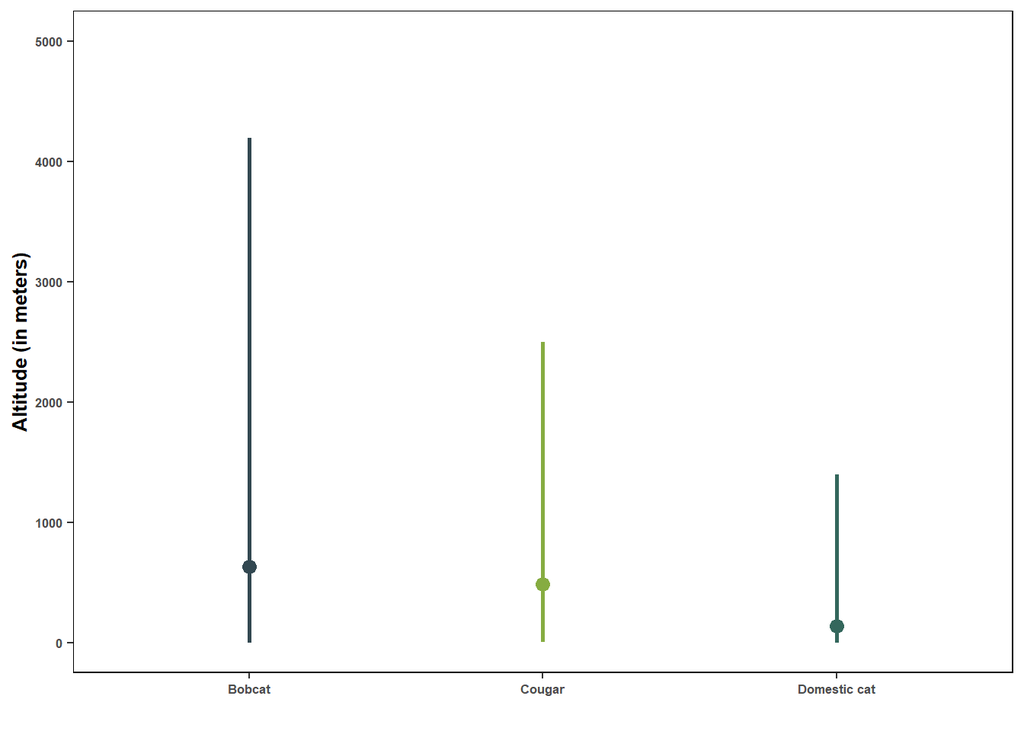

```r
# calculate lower and upper range and median elevation of each species
dfel <- dfel %>%
  group_by(species) %>%
  summarize(lower = min(elev), upper = max(elev), median = median(elev))

# use common names rather than scientific names for species
dfel <- dfel %>%
  mutate(species = recode(species, 'Felis catus' = 'Domestic cat', 'Lynx rufus' = 'Bobcat', 'Puma concolor' = 'Cougar'))
# be default, species will appear in alphabetical order. Here the order is convenient but here is how to change it if necessary
# change the factor levels to change the order in which they are placed on x-axis
# by descending altitude
dfel$species <- factor(dfel$species, levels = c("Bobcat", "Cougar", "Domestic cat"))

g1 <- ggplot(dfel, aes(x = species, y = median, col = species)) +
  # use basic line range instead of boxplot
  geom_point(size = 3) +
  geom_linerange(aes(ymin = lower, ymax = upper), size = 1) +
  # instead of using the units 'm', spell out 'in meters'
  scale_y_continuous("Altitude (in meters)", limits = c(0, 5000)) +
  scale_x_discrete(name = "") +
  scale_color_canva(guide = F, palette = "Playful greens and blues") +
  theme(panel.border = element_rect(size=0.5,color="black", fill="transparent"), #white background
        panel.background = element_rect(fill = 'transparent', colour = NA),
        plot.background = element_rect(fill = "transparent", colour = NA),
        panel.grid.major = element_line(size = 0.2, color = "white"),
        panel.grid.minor = element_blank(),
        text=element_text(face="bold", size=8), #general size for all text.looks small here but ok once using ggsave with 600 dpi and default pointsize
        title = element_text(size=rel(1.2))) # all titles will be a little larger than labels
g1
```

```r
ggsave(g1, file = "Challenge4_figure_for_outreach.png", width = 88, height = 88, dpi = 600, units = "mm",  bg = "transparent")
```

I exported the figure in png format with transparent background and uploaded it to my canva account to create the final figure below.

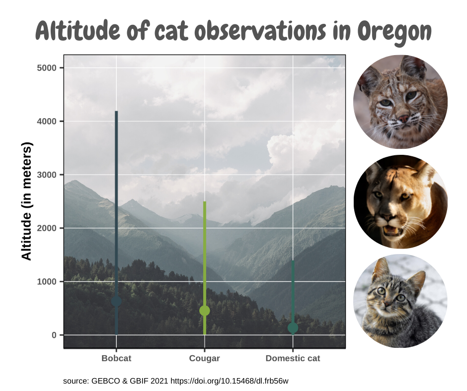

```r
img1_path <- "Challenge4_figure_for_outreach_part2.png"
include_graphics(img1_path)
```